# Group-26 AAD-Assignment-2

Omar, Eloise, Alina, Sue

2025-05-20

# 2.1 Nonlinear model vs non-parametric model

## 2.1.1 GAM vs KNN approach

## 2.1.2 GAM vs KNN Regression Model

We will use the cleaned data (omitting all data point that contains “NA”) instead of the original raw dataset. We split the data into a training set (80% of the original data) and a test set (20% of the original data).

```r
# load the data
data <- read.csv("Assignt2_data.csv")
data <- na.omit(data)
```

```r
# separate the training and test set out
set.seed(1)
train_index <- createDataPartition(data$medianHouseValue, p = 0.8, list = FALSE)
train_data <- data[train_index, ]
test_data  <- data[-train_index, ]
```

### Basic KNN Regression Model

The basic KNN regression model was trained using 5-fold cross-validation on the training dataset, with k tuned from 1 to 10. Preprocessing steps included centering and scaling to ensure features contribute equally to the distance metric.

```r
# Basic KNN

knn_reg_model_1 <- train(
  medianHouseValue ~ .,
  data = train_data,
  method = "knn",
  preProcess = c("center", "scale"),
  tuneGrid = data.frame(k = 1:10),  # test k = 1 to 10
  trControl = trainControl(method = "cv", number = 5)
)

# best k
print(knn_reg_model_1)
```

```
## k-Nearest Neighbors
##
## 16348 samples
##     9 predictor
##
## Pre-processing: centered (12), scaled (12)
## Resampling: Cross-Validated (5 fold)
## Summary of sample sizes: 13080, 13078, 13077, 13079, 13078
## Resampling results across tuning parameters:
##
##   k   RMSE      Rsquared   MAE
##    1  78263.78  0.5866013  51134.82
##    2  68539.95  0.6576558  45714.66
##    3  65188.16  0.6840453  43863.05
##    4  63511.49  0.6981273  42904.46
##    5  62763.65  0.7044630  42476.71
##    6  62320.09  0.7082957  42184.58
##    7  62295.64  0.7084690  42252.06
##    8  62324.43  0.7082763  42194.31
##    9  62180.58  0.7096554  42039.43
##   10  62165.35  0.7098677  42030.93
##
## RMSE was used to select the optimal model using the smallest value.
## The final value used for the model was k = 10.
```

```r
# KNN MSE calculation
knn_pred_1 <- predict(knn_reg_model_1, newdata = test_data)
knn_MSE_1 <- mean((knn_pred_1 - test_data$medianHouseValue)^2)
cat("The test MSE of basic KNN model is", knn_MSE_1, "\n")
```

```
## The test MSE of basic KNN model is 3697939911
```

```r
# The KNN MSE is 3697939911
```

The test MSE of basic KNN model is 3,697,939,911

### KNN Model Improvements

```r
# import and clean data to get data_imp for model improvement
data_imp <- read.csv("Assignt2_data.csv")
data_imp <- na.omit(data_imp)

# bedroomsPerRoom
data_imp$bedroomsPerRoom <- data_imp$aveBedrooms / data_imp$aveRooms

# incomePerRoom
data_imp$incomePerRoom = data_imp$medianIncome / data_imp$aveRooms

# Compute distances
la_coords <- c(-118.24, 34.05)   # (longitude, latitude)
sf_coords <- c(-122.42, 37.77)

data_imp$distToLA <- apply(data_imp[, c("longitude", "latitude")], 1, function(coord) {
  distGeo(coord, la_coords) / 1000
})
data_imp$distToSF <- apply(data_imp[, c("longitude", "latitude")], 1, function(coord) {
  distGeo(coord, sf_coords) / 1000
})

# Compute directions
data_imp$dirToLA <- atan2(data_imp$latitude - la_coords[2], data_imp$longitude - la_coords[1])
data_imp$dirToSF <- atan2(data_imp$latitude - sf_coords[2], data_imp$longitude - sf_coords[1])

# Cosine and sine of direction
data_imp$cosDirToLA <- cos(data_imp$dirToLA)
data_imp$sinDirToLA <- sin(data_imp$dirToLA)
data_imp$cosDirToSF <- cos(data_imp$dirToSF)
data_imp$sinDirToSF <- sin(data_imp$dirToSF)
data_imp$dirToLA <- NULL
data_imp$dirToSF <- NULL

# Composite proximity score
data_imp$cityProximityScore <- 1 / (1 + data_imp$distToLA) + 1 / (1 + data_imp$distToSF)

# Add these to test and train
train_data_imp <- data_imp[train_index, ]
test_data_imp  <- data_imp[-train_index, ]
```

```r
# KNN with model improvements cont.

# Hot encoding the variables

# Convert oceanProximity to factor (if not already)
train_data_imp$oceanProximity <- as.factor(train_data_imp$oceanProximity)
test_data_imp$oceanProximity <- as.factor(test_data_imp$oceanProximity)

# One-hot encode using dummyVars
dummies <- dummyVars(~ ., data = train_data_imp)
train_data_encoded <- predict(dummies, newdata = train_data_imp)
test_data_encoded <- predict(dummies, newdata = test_data_imp)

# Convert to data frame
train_data_encoded <- as.data.frame(train_data_encoded)
test_data_encoded <- as.data.frame(test_data_encoded)


set.seed(1)
knn_reg_model_2 <- train(
  medianHouseValue ~ .,
  data = train_data_encoded,
  method = "knn",
  preProcess = c("center", "scale"),
  tuneGrid = data.frame(k = 1:15),  # test k = 1 to 15
  trControl = trainControl(method = "cv", number = 5)
)

# best k
print(knn_reg_model_2)
```

```
## k-Nearest Neighbors
##
## 16348 samples
##    22 predictor
##
## Pre-processing: centered (22), scaled (22)
## Resampling: Cross-Validated (5 fold)
## Summary of sample sizes: 13079, 13079, 13079, 13077, 13078
## Resampling results across tuning parameters:
##
##   k   RMSE      Rsquared   MAE
##    1  66385.89  0.6909631  42440.24
##    2  58381.64  0.7484709  37953.75
##    3  55933.47  0.7661884  36627.25
##    4  55004.24  0.7730937  36111.73
##    5  54317.70  0.7785023  35764.88
##    6  53945.80  0.7814824  35613.56
##    7  53578.94  0.7845326  35438.22
##    8  53712.63  0.7835900  35519.56
##    9  53752.89  0.7834049  35538.46
##   10  53830.31  0.7829121  35625.21
##   11  54033.34  0.7814496  35738.22
##   12  54202.30  0.7802226  35894.73
##   13  54302.01  0.7795432  35978.73
##   14  54460.42  0.7784005  36082.95
##   15  54668.36  0.7768853  36207.29
##
## RMSE was used to select the optimal model using the smallest value.
## The final value used for the model was k = 7.
```

```r
# KNN MSE calculation
knn_pred_2 <- predict(knn_reg_model_2, newdata = test_data_encoded)
knn_MSE_2 <- mean((knn_pred_2 - test_data_encoded$medianHouseValue)^2)
cat("The KNN MSE (improved) is", knn_MSE_2, "\n")
```

```
## The KNN MSE (improved) is 2999761722
```

```r
#The KNN MSE is 3697939911 with out encoding
#With encoding  3694531899
#PCA makes it worse in general
#improve when tested more k 3650562433
# best now is: 2999761722
```

### Basic GAM

```r
# GAM

# train the GAM
set.seed(1)
gam_model_1 <- mgcv::gam(medianHouseValue ~ s(latitude) +
                           s(longitude) +
                   s(housingMedianAge) +
                     s(aveRooms) +
                   s(aveBedrooms) +
                     s(population) +
                   s(medianIncome) +
                     factor(oceanProximity),
                   data = train_data,
                   select = TRUE)

# Calculate MSE
gam_pred_1 <- predict(gam_model_1, newdata = test_data)
gam_MSE_1 <- mean((gam_pred_1 - test_data$medianHouseValue)^2)
cat("The Basic GAM MSE is", gam_MSE_1, "\n")
```

```
## The Basic GAM MSE is 4257370057
```

```r
# 4257370057
```

### Improved GAM

```r
# GAM improvements
train_data_imp = data_imp[train_index, ]
set.seed(1)
gam_model_2 <- mgcv::gam(medianHouseValue ~
                     s(housingMedianAge) +
                     s(aveRooms) +
                     s(aveBedrooms) +
                     s(population) +
                     s(medianIncome) +
                     te(longitude, latitude) +
                     s(cityProximityScore) +
                     s(bedroomsPerRoom) +
                     s(incomePerRoom) +
                     s(distToSF) +
                     s(distToLA) +
                     s(cosDirToLA) +
                     s(cosDirToSF) +
                     s(sinDirToLA) +
                     s(sinDirToSF),
                   data = train_data_imp,
                   select = TRUE)


# Calculate MSE
test_data_imp = data_imp[-train_index, ]
gam_pred_2 <- predict(gam_model_2, newdata = test_data_imp)
gam_MSE_2 <- mean((gam_pred_2 - test_data_imp$medianHouseValue)^2)
cat("The GAM MSE (improved) is", gam_MSE_2, "\n")
```

```
## The GAM MSE (improved) is 3386501790
```

```r
# 3386501790
```

## 2.1.3 Which model performs better?

Without adding any new features, KNN regression has a lower test MSE (3,697,939,911) that is about 13% lower than the GAM (test MSE = 4,257,370,057). The baseline models were tuned - KNN with 5-fold cross-validation to select the optimal k, and GAM with automatic feature selection.

# 2.2 Classification models

## 2.2.1 New censoring boolean column

```r
# Add censoring column and drop id and medianHouseValue
data_c <- data %>%
  na.omit() %>%
  mutate(censoring = ifelse(medianHouseValue == 500001, 1, 0)) %>%
  dplyr::select(-id, -medianHouseValue) %>%
  mutate(oceanProximity = as.factor(oceanProximity))



# This dataframe does the same changes as above but is with our model improvements
data_c_imp <- data_imp %>%
  na.omit() %>%
  mutate(censoring = ifelse(medianHouseValue == 500001, 1, 0)) %>%
  dplyr::select(-id, -medianHouseValue) %>%
  mutate(oceanProximity = as.factor(oceanProximity))
```

## 2.2.2 Two classification methods

In this case KNN-CV is a non-parametric approach that classifies each block group by majority voting among its $k$ closest neighbours in the predictor space. Formally, for a test point $x_0$, let $N_0$ be the indices of the $k$ nearest training observations (by Euclidean distance):

$$Pr(\text{censor} = 1|x_0) =
\frac{1}{k}\sum_{i\in N_0}I(\text{censor}_i = 1)$$

and we predict the class with the larger estimated probability. We choose $k$ via cross-validation to pick the optimal bias-variance trade-off. \

## 2.2.3 Which classification method performs better?

```r
# Logistic Regression without Model Improvements

train_data_c <- data_c[train_index, ]
test_data_c <- data_c[-train_index, ]

logit_fit_1 <- glm(censoring ~ longitude +
                   latitude +
                   medianIncome +
                   housingMedianAge +
                   oceanProximity +
                   aveRooms +
                   aveBedrooms,
                 data = train_data_c,
                 family = binomial)

logit_pred_1 <- as.numeric(predict(logit_fit_1,
                      newdata = test_data_c,
                      type = "response") > 0.5) # use 0.5 for now

error_rate <- mean(logit_pred_1 != test_data_c$censoring)

print(paste("Logistic Regression Prediction Error Rate:", round(error_rate, 3)))
```

```
## [1] "Logistic Regression Prediction Error Rate: 0.031"
```

```r
#library(caret)
# Confusion matrix
confusion_matrix <- confusionMatrix(as.factor(logit_pred_1), as.factor(test_data_c$censoring))
print(confusion_matrix)
```

```
## Confusion Matrix and Statistics
##
##           Reference
## Prediction    0    1
##          0 3857  107
##          1   20  101
##
##                Accuracy : 0.9689
##                  95% CI : (0.9631, 0.974)
##     No Information Rate : 0.9491
##     P-Value [Acc > NIR] : 4.094e-10
##
##                   Kappa : 0.599
##
##  Mcnemar's Test P-Value : 2.325e-14
##
##             Sensitivity : 0.9948
##             Specificity : 0.4856
##          Pos Pred Value : 0.9730
##          Neg Pred Value : 0.8347
##              Prevalence : 0.9491
##          Detection Rate : 0.9442
##    Detection Prevalence : 0.9704
##       Balanced Accuracy : 0.7402
##
##        'Positive' Class : 0
##
```

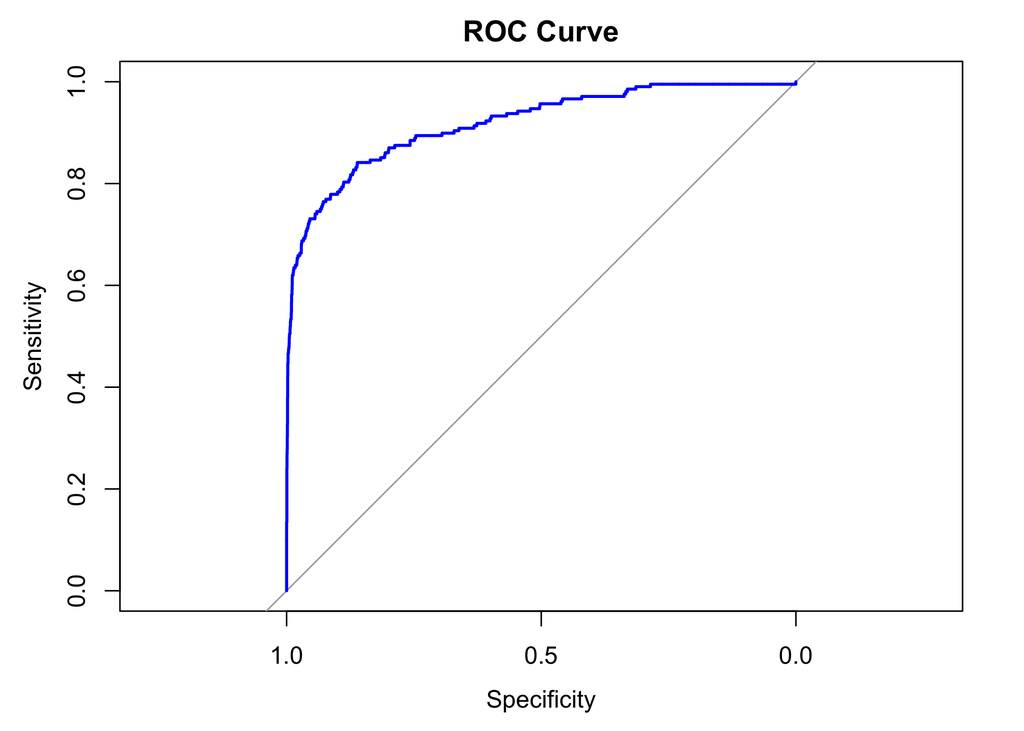

```r
# ROC
#library(caret)
#library(pROC)
logit_pred_probs_1 <- predict(logit_fit_1, newdata = test_data_c, type = "response")
roc_curve_1 <- roc(test_data_c$censoring, logit_pred_probs_1)
plot(roc_curve_1, main = "ROC Curve", col = "blue", lwd = 2)
```

```r
# error rate: 0.031
```

```r
# Logistic Regression with Model Improvements

train_data_c_imp <- data_c_imp[train_index, ]
test_data_c_imp <- data_c_imp[-train_index, ]

logit_fit_2 <- glm(censoring ~ longitude +
                   latitude +
                   medianIncome +
                   housingMedianAge +
                   oceanProximity +
                   aveRooms +
                   aveBedrooms +
                   cityProximityScore +
                   bedroomsPerRoom +
                   incomePerRoom +
                   distToSF +
                   distToLA +
                   cosDirToLA +
                   cosDirToSF +
                   sinDirToLA +
                   sinDirToSF,
                 data = train_data_c_imp,
                 family = binomial)
logit_pred_2 <- as.numeric(predict(logit_fit_2,
                      newdata = test_data_c_imp,
                      type = "response") > 0.5) # use 0.5 for now

error_rate <- mean(logit_pred_2 != test_data_c_imp$censoring)

print(paste("Logistic Regression Prediction Error Rate:", round(error_rate, 3)))
```

```
## [1] "Logistic Regression Prediction Error Rate: 0.029"
```

```r
#library(caret)
# Confusion matrix
confusion_matrix <- confusionMatrix(as.factor(logit_pred_2), as.factor(test_data_c_imp$censoring))
print(confusion_matrix)
```

```
## Confusion Matrix and Statistics
##
##           Reference
## Prediction    0    1
##          0 3854   95
##          1   23  113
##
##                Accuracy : 0.9711
##                  95% CI : (0.9655, 0.976)
##     No Information Rate : 0.9491
##     P-Value [Acc > NIR] : 2.686e-12
##
##                   Kappa : 0.6426
##
##  Mcnemar's Test P-Value : 6.315e-11
##
##             Sensitivity : 0.9941
##             Specificity : 0.5433
##          Pos Pred Value : 0.9759
##          Neg Pred Value : 0.8309
##              Prevalence : 0.9491
##          Detection Rate : 0.9435
##    Detection Prevalence : 0.9667
##       Balanced Accuracy : 0.7687
##
##        'Positive' Class : 0
##
```

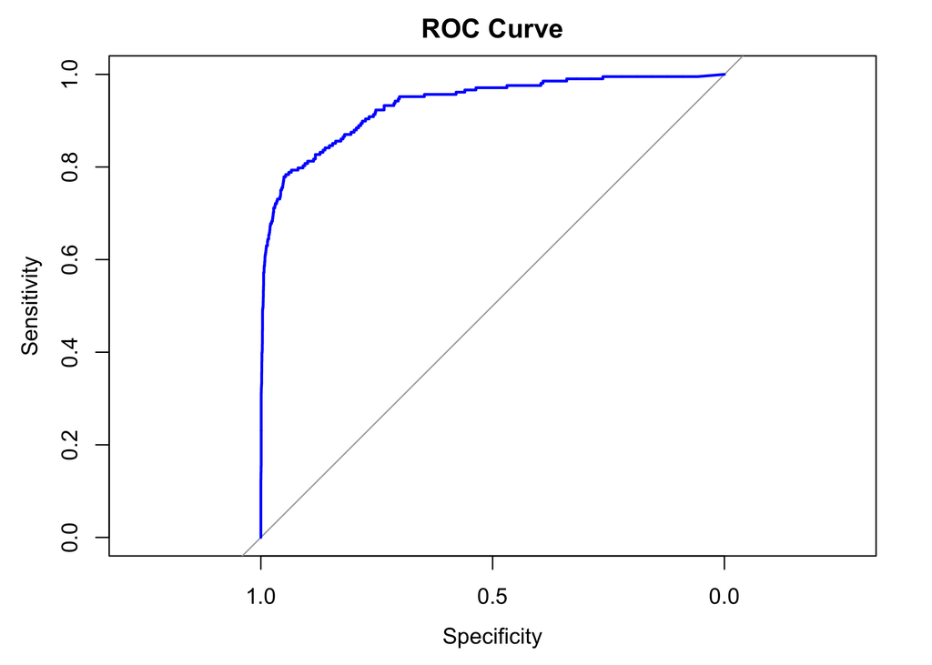

```r
# ROC
#library(caret)
#library(pROC)
logit_pred_probs_2 <- predict(logit_fit_2, newdata = test_data_c_imp, type = "response")
roc_curve_2 <- roc(test_data_c_imp$censoring, logit_pred_probs_2)
plot(roc_curve_2, main = "ROC Curve", col = "blue", lwd = 2)
```

```r
# error rate: 0.029
```

```r
## KNN-CV Without Model Improvements

# Prepare the predictors (X) and response (Y)
train.X <- model.matrix(~ longitude +
                          latitude +
                          housingMedianAge +
                          aveRooms +
                          aveBedrooms +
                          population +
                          medianIncome +
                          oceanProximity,
                        data = train_data_c)[, -1]

test.X <- model.matrix(~ longitude +
                         latitude +
                         housingMedianAge +
                         aveRooms +
                         aveBedrooms +
                         population +
                         medianIncome +
                         oceanProximity,
                       data = test_data_c)[, -1]

train.Y <- train_data_c$censoring
test.Y <- test_data_c$censoring

# Use cross-validation on the training set to choose the best k
knn_rp <- rep(0, 15)
for (k in 1:15) {
  set.seed(5)
  knn.pred.cv <- knn.cv(train = train.X, cl = train.Y, k = k)
  knn_rp[k] <- mean(knn.pred.cv == train.Y)
}

k.cv <- which.max(knn_rp)
cat("Best k selected by CV is:", k.cv, "\n")
```

```
## Best k selected by CV is: 5
```

```r
# Fit and predict on the test set using the best k
set.seed(5)
knn_pred_c_1 <- knn(train = train.X, test = test.X, cl = train.Y, k = k.cv)

# Compute confusion matrix and error rate
confusionMatrix(as.factor(knn_pred_c_1), as.factor(test.Y))
```

```
## Confusion Matrix and Statistics
##
##           Reference
## Prediction    0    1
##          0 3876  199
##          1    1    9
##
##                Accuracy : 0.951
##                  95% CI : (0.944, 0.9575)
##     No Information Rate : 0.9491
##     P-Value [Acc > NIR] : 0.2994
##
##                   Kappa : 0.0783
##
##  Mcnemar's Test P-Value : <2e-16
##
##             Sensitivity : 0.99974
##             Specificity : 0.04327
##          Pos Pred Value : 0.95117
##          Neg Pred Value : 0.90000
##              Prevalence : 0.94908
##          Detection Rate : 0.94884
##    Detection Prevalence : 0.99755
##       Balanced Accuracy : 0.52151
##
##        'Positive' Class : 0
##
```

```r
(knn_err_c_1 = mean(knn_pred_c_1 != test.Y))
```

```
## [1] 0.04895961
```

```r
cat("The KNN error rate is", round(knn_err_c_1, 4), "\n")
```

```
## The KNN error rate is 0.049
```

```r
#The KNN error rate is 0.049
```

```r
## KNN-CV with Model Improvements

# Prepare the predictors (X) and response (Y)
train.X <- model.matrix(~ longitude +
                          latitude +
                          medianIncome +
                          housingMedianAge +
                          oceanProximity +
                          aveRooms +
                          aveBedrooms +
                          cityProximityScore +
                          bedroomsPerRoom +
                          incomePerRoom +
                          distToSF +
                          distToLA +
                          cosDirToLA +
                          cosDirToSF +
                          sinDirToLA +
                          sinDirToSF,
                        data = train_data_c_imp)[, -1]

test.X <- model.matrix(~  longitude +
                          latitude +
                          medianIncome +
                          housingMedianAge +
                          oceanProximity +
                          aveRooms +
                          aveBedrooms +
                          cityProximityScore +
                          bedroomsPerRoom +
                          incomePerRoom +
                          distToSF +
                          distToLA +
                          cosDirToLA +
                          cosDirToSF +
                          sinDirToLA +
                          sinDirToSF,
                       data = test_data_c_imp)[, -1]

train.Y <- train_data_c_imp$censoring
test.Y <- test_data_c_imp$censoring

# Use cross-validation on the training set to choose the best k
knn_rp <- rep(0, 15)
for (k in 1:15) {
  set.seed(5)
  knn.pred.cv <- knn.cv(train = train.X, cl = train.Y, k = k)
  knn_rp[k] <- mean(knn.pred.cv == train.Y)
}

k.cv <- which.max(knn_rp)
cat("Best k selected by CV is:", k.cv, "\n")
```

```
## Best k selected by CV is: 5
```

```r
# Fit and predict on the test set using the best k
set.seed(5)
knn_pred_c_2 <- knn(train = train.X, test = test.X, cl = train.Y, k = k.cv)

# Compute confusion matrix and error rate
confusionMatrix(as.factor(knn_pred_c_2), as.factor(test.Y))
```

```
## Confusion Matrix and Statistics
##
##           Reference
## Prediction    0    1
##          0 3859  107
##          1   18  101
##
##                Accuracy : 0.9694
##                  95% CI : (0.9636, 0.9745)
##     No Information Rate : 0.9491
##     P-Value [Acc > NIR] : 1.419e-10
##
##                   Kappa : 0.603
##
##  Mcnemar's Test P-Value : 3.519e-15
##
##             Sensitivity : 0.9954
##             Specificity : 0.4856
##          Pos Pred Value : 0.9730
##          Neg Pred Value : 0.8487
##              Prevalence : 0.9491
##          Detection Rate : 0.9447
##    Detection Prevalence : 0.9709
##       Balanced Accuracy : 0.7405
##
##        'Positive' Class : 0
##
```

```r
(knn_err_c_2 = mean(knn_pred_c_2 != test.Y))
```

```
## [1] 0.03059976
```

```r
cat("The KNN error rate is", round(knn_err_c_2, 4), "\n")
```

```
## The KNN error rate is 0.0306
```

```r
#The KNN error rate is 0.0306
```

Note: We did not generate ROC curves for KNN because it does not provide continuous probability scores but rather hard class labels. ROC analysis requires varying the classification threshold across a range of values, which is not possible with the standard KNN output. While probabilistic adaptations of KNN exist, they were not necessary here since our objective was classification accuracy, not probability estimation.

## 2.2.4 Justifying the better classification method

Logistic regression outperformed KNN-CV in our 80/20 hold-out test, with test errors of 0.0290 and 0.0306 respectively. Logistic regression is a parametric model, it assumes a specific relationship between predictors and the target, resulting in higher bias but lower variance. This rigidity works in its favour when the underlying structure of the data is close to linear, as it avoids fitting noise and reduces the risk of overfitting. KNN, on the other hand, is non-parametric and makes very few assumptions about the data’s form. It is flexible and can capture complex, non-linear patterns, but that flexibility comes at the cost of high variance, especially in high-dimensional settings.

While KNN’s flexibility can be useful, it becomes increasingly unstable in high-dimensional spaces where data points are more sparsely distributed and neighbourhoods lose their meaning. Specifically, the distance between the nearest and farthest neighbours shrinks, making it hard to define what counts as “close,” which undermines the core logic of KNN. Even with cross-validation to choose the optimal k, KNN was still overfitting, likely due to this dimensionality issue. Logistic regression, despite its linear constraint, handled the complexity of the data more gracefully by not reacting too much to the noise.

The lower test error achieved by logistic regression shows that its higher bias was actually beneficial here, it provided a smoother, more stable model that generalised well. So while KNN theoretically offers more flexibility, in this case it became a liability, and logistic regression ultimately struck the better balance. To note, the test error is only marginally larger for the KNN, and both are relatively low so it is clear that both models are effective, just for this random seed logistic regression is the winner.

# 2.3 A hybrid approach

## 2.3.1 Dicussing feasibility of the approach

To address the censoring issue in the dataset, a hybrid approach that combines regression and classification models is both feasible and potentially very effective. The best regression model from 2.1.3 is used to predict house values, while the best classifier from 2.2.2 identifies whether a given observation is censored; i.e. whether the true house value exceeds the $500,001 threshold. This setup allows us to adjust regression predictions when the classifier indicates censoring, helping to reduce the bias that occurs when censored values are treated as if they were exact rather than right censored.

The procedure involves four main steps. First, we use the KNN regression model to predict house prices. Second, a logistic regression classifier estimates the probability of censoring. Third, we adjust the regression predictions by setting them to 500001 for observations predicted to be censored. Finally, we evaluate the performance of this adjusted model using test MSE. This combined method leverages the strengths of both models and is a practical way to improve prediction accuracy in the presence of censoring.

## 2.3.2 test MSE of medianHousingValue using the approach

```r
# Step 1: Predict house prices with KNN regression
knn_pred_2 <- predict(knn_reg_model_2, newdata = test_data_encoded)

# Step 2: Predict censoring with logistic regression
logit_pred_2 <- as.numeric(predict(logit_fit_2, newdata = test_data_c_imp, type = "response") > 0.5)

# Step 3: Adjust predicted house prices
# If censored predicted, clip to 500001
adjusted_preds <- ifelse(logit_pred_2 == 1, 500001, knn_pred_2)

# Step 4: Compute MSE using all observations
final_mse <- mean((adjusted_preds - test_data_encoded$medianHouseValue)^2)

cat("Final Test MSE:", round(final_mse, 2), "\n")
```

```
## Final Test MSE: 3025628814
```

```r
# Final Test MSE: 2997065945
# this is worse then KNN_2
```

## 2.3.3 Comparison of the accuracy of this procedure to model in 2.1.3

The combined model clips predictions to 500001 when the logistic model predicts censoring, but if that prediction is wrong, it forces the value far from the true (uncensored) price, increasing error. KNN, on the other hand, always predicts a value — even for censored cases — and sometimes lands closer to the unknown true price (which is at least 500001), purely by chance. This makes KNN appear to perform better in terms of MSE, even though it doesn’t account for censoring and might be underestimating the true values.

The hybrid model resulted in a slightly higher test MSE (3,025,628,814) compared to the original KNN regression model from 2.1.3 (2,999,761,722). These results were obtained using a random 80/20 train-test split of the data the same split used throughout the course of this report. Given how close the two MSE values are, it’s possible that on a different random sample, the hybrid model could perform slightly better. Overall, the difference is minimal, suggesting that both models offer comparable predictive performance in this context.

The reason the hybrid model does not consistently outperform KNN likely stems from how it handles censoring using a hard classification decision. Specifically, it clips predicted values to 500001 whenever the logistic classifier predicts an observation is censored. This is because logistic regression applies a strict decision boundary (at 0.5) to make this call, which introduces a sharp threshold with no gradual transition. This can be problematic near the boundary, where small changes in input may flip the classification, yet the model treats the output as definitively censored or not. If the classifier incorrectly predicts censoring, the hard cap forces the prediction to 500001, which can be significantly off from the true (uncensored) value. In contrast, the KNN model always outputs a continuous estimate. When the classifier misclassifies an uncensored point as censored, the true value is often still closer to the KNN prediction than to the fixed 500001. As a result, KNN may show better MSE performance, despite not explicitly addressing censoring.